# Final

Sasha

First step is to creat SQLlite database

```r
library(nycflights13)
library(dplyr)
library(ggplot2)
library (RSQLite)

sasha <- src_sqlite("sasha.sqlite27", create = T)

flights_sqlite <- copy_to(
  sasha, flights, temporary = FALSE,
  indexes = list(
    c("year", "month", "day"),
    "carrier",
    "tailnum")
)

airlines_sqlite <- copy_to(
  sasha, airlines, temporary = FALSE,
  indexes = list("carrier")
)

airports_sqlite <- copy_to(
  sasha, airports, temporary = FALSE,
  indexes = list("faa")
)

planes_sqlite <- copy_to(
  sasha, planes, temporary = FALSE,
  indexes = list("tailnum")
)

weather_sqlite <- copy_to(
  sasha, weather, temporary = FALSE,
  indexes = list(
    c("year", "month","day","hour"),
    "origin")
)

nycflights13_sqlite()
```

```
## src:  sqlite 3.8.6 [/var/folders/7r/2fyj6b89787_l_xn6v9hcxm00000gn/T//Rtmp5ieDYO/nycflights13.sqlite]
## tbls: airlines, airports, flights, planes, sqlite_stat1, weather
```

```r
sasha
```

```
## src:  sqlite 3.8.6 [sasha.sqlite27]
## tbls: airlines, airports, flights, planes, sqlite_stat1, weather
```

```r
flights_sqlite <- tbl(sasha, "flights")
flights_sqlite
```

```
## Source: sqlite 3.8.6 [sasha.sqlite27]
## From: flights [336,776 x 16]
##
##     year month   day dep_time dep_delay arr_time arr_delay carrier tailnum
##    (int) (int) (int)    (int)     (dbl)    (int)     (dbl)   (chr)   (chr)
## 1   2013     1     1      517         2      830        11      UA  N14228
## 2   2013     1     1      533         4      850        20      UA  N24211
## 3   2013     1     1      542         2      923        33      AA  N619AA
## 4   2013     1     1      544        -1     1004       -18      B6  N804JB
## 5   2013     1     1      554        -6      812       -25      DL  N668DN
## 6   2013     1     1      554        -4      740        12      UA  N39463
## 7   2013     1     1      555        -5      913        19      B6  N516JB
## 8   2013     1     1      557        -3      709       -14      EV  N829AS
## 9   2013     1     1      557        -3      838        -8      B6  N593JB
## 10  2013     1     1      558        -2      753         8      AA  N3ALAA
## ..   ...   ...   ...      ...       ...      ...       ...     ...     ...
## Variables not shown: flight (int), origin (chr), dest (chr), air_time
##   (dbl), distance (dbl), hour (dbl), minute (dbl)
```

part A 1.analyze the relationship between weather and departure by using liner model regression.

```r
flights_weather_join <- left_join(
  tbl(sasha, "flights"),
  tbl(sasha, "weather"),
  by = "origin")

lm_delay_temp<-lm(dep_delay~temp,flights_weather_join)
summary(lm_delay_temp)
```

```
##
## Call:
## lm(formula = dep_delay ~ temp, data = flights_weather_join)
##
## Residuals:
##     Min      1Q  Median      3Q     Max
## -6.8045 -2.6985  0.3175  2.2891 14.2934
##
## Coefficients:
##              Estimate Std. Error t value Pr(>|t|)
## (Intercept) -1.601558   0.040879 -39.178  < 2e-16 ***
## temp         0.004058   0.000703   5.773 7.81e-09 ***
## ---
## Signif. codes:  0 '***' 0.001 '**' 0.01 '*' 0.05 '.' 0.1 ' ' 1
##
## Residual standard error: 4.071 on 99987 degrees of freedom
##   (11 observations deleted due to missingness)
## Multiple R-squared:  0.0003332,  Adjusted R-squared:  0.0003232
## F-statistic: 33.33 on 1 and 99987 DF,  p-value: 7.811e-09
```

```r
lm_delay_dewp<-lm(dep_delay~dewp,flights_weather_join)
summary(lm_delay_dewp)
```

```
##
## Call:
## lm(formula = dep_delay ~ dewp, data = flights_weather_join)
##
## Residuals:
##     Min      1Q  Median      3Q     Max
## -6.7565 -2.7025  0.3164  2.2821 14.2786
##
## Coefficients:
##               Estimate Std. Error t value Pr(>|t|)
## (Intercept) -1.5389214  0.0301242 -51.086  < 2e-16 ***
## dewp         0.0038907  0.0006567   5.924 3.14e-09 ***
## ---
## Signif. codes:  0 '***' 0.001 '**' 0.01 '*' 0.05 '.' 0.1 ' ' 1
##
## Residual standard error: 4.071 on 99987 degrees of freedom
##   (11 observations deleted due to missingness)
## Multiple R-squared:  0.0003509,  Adjusted R-squared:  0.0003409
## F-statistic:  35.1 on 1 and 99987 DF,  p-value: 3.145e-09
```

```r
lm_delay_humid<-lm(dep_delay~humid,flights_weather_join)
summary(lm_delay_humid)
```

```
##
## Call:
## lm(formula = dep_delay ~ humid, data = flights_weather_join)
##
## Residuals:
##     Min      1Q  Median      3Q     Max
## -6.6591 -2.6421  0.3627  2.3530 14.3668
##
## Coefficients:
##               Estimate Std. Error t value Pr(>|t|)
## (Intercept) -1.4394475  0.0431362 -33.370   <2e-16 ***
## humid        0.0009856  0.0006558   1.503    0.133
## ---
## Signif. codes:  0 '***' 0.001 '**' 0.01 '*' 0.05 '.' 0.1 ' ' 1
##
## Residual standard error: 4.071 on 99987 degrees of freedom
##   (11 observations deleted due to missingness)
## Multiple R-squared:  2.259e-05,  Adjusted R-squared:  1.259e-05
## F-statistic: 2.259 on 1 and 99987 DF,  p-value: 0.1329
```

```r
lm_delay_winddir<-lm(dep_delay~wind_dir,flights_weather_join)
summary(lm_delay_winddir)
```

```
##
## Call:
## lm(formula = dep_delay ~ wind_dir, data = flights_weather_join)
##
## Residuals:
##     Min      1Q  Median      3Q     Max
## -6.6392 -2.6348  0.3714  2.3625 14.3793
##
## Coefficients:
##               Estimate Std. Error t value Pr(>|t|)
## (Intercept) -1.361e+00  2.628e-02  -51.77   <2e-16 ***
## wind_dir    -8.844e-05  1.180e-04   -0.75    0.453
## ---
## Signif. codes:  0 '***' 0.001 '**' 0.01 '*' 0.05 '.' 0.1 ' ' 1
##
## Residual standard error: 4.071 on 97333 degrees of freedom
##   (2665 observations deleted due to missingness)
## Multiple R-squared:  5.775e-06,  Adjusted R-squared:  -4.499e-06
## F-statistic: 0.5621 on 1 and 97333 DF,  p-value: 0.4534
```

```r
lm_delay_windspeed<-lm(dep_delay~wind_speed,flights_weather_join)
summary(lm_delay_windspeed)
```

```
##
## Call:
## lm(formula = dep_delay ~ wind_speed, data = flights_weather_join)
##
## Residuals:
##     Min      1Q  Median      3Q     Max
## -6.6312 -2.6269  0.3742  2.3720 14.3763
##
## Coefficients:
##               Estimate Std. Error t value Pr(>|t|)
## (Intercept) -1.3687861  0.0160598  -85.23   <2e-16 ***
## wind_speed  -0.0009329  0.0010246   -0.91    0.363
## ---
## Signif. codes:  0 '***' 0.001 '**' 0.01 '*' 0.05 '.' 0.1 ' ' 1
##
## Residual standard error: 4.071 on 99986 degrees of freedom
##   (12 observations deleted due to missingness)
## Multiple R-squared:  8.291e-06,  Adjusted R-squared:  -1.711e-06
## F-statistic: 0.8289 on 1 and 99986 DF,  p-value: 0.3626
```

The coefficients of first two regression are significant, the coefficients of the other regression are all not significant. Which indicates the temperature and dewpoint can explain the changing in departure better.

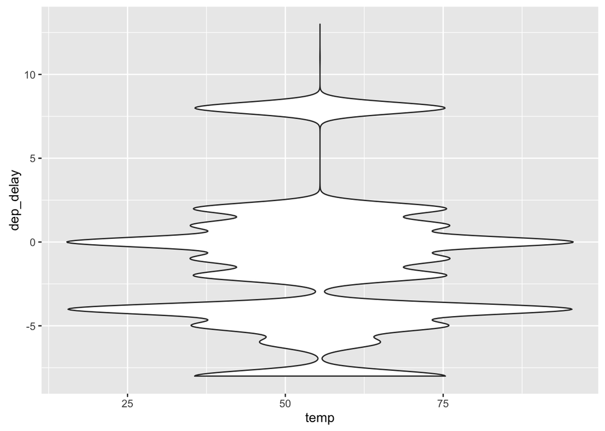

```r
flights_weather_join<- data.frame(flights_weather_join)
a<-ggplot(flights_weather_join,aes(x=temp,y=dep_delay))
a + geom_violin()
```

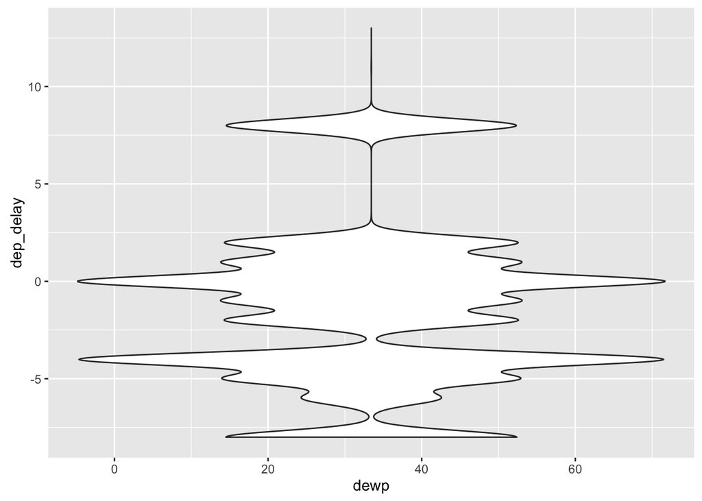

```r
b<-ggplot(flights_weather_join,aes(x=dewp,y=dep_delay))
b+ geom_violin()
```

2.analyse the relationship between departureand time of day, day of week, time of year

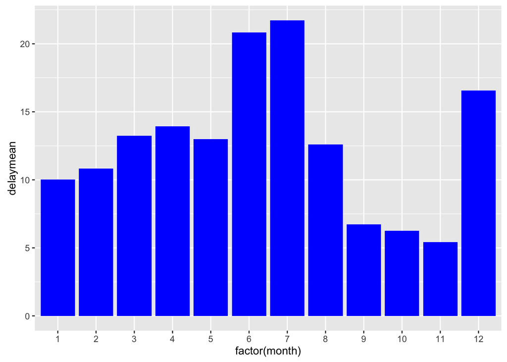

```r
flights.delaysum.sql_year <- tbl(sasha, "flights") %>%
  group_by(year) %>%
  summarize(
    delaymean = mean(dep_delay)
  ) %>% collect()

flights.delaysum.sql_month <- tbl(sasha, "flights") %>%
  group_by(month) %>%
  summarize(
    delaymean = mean(dep_delay)
  )%>%collect()

flights.delaysum.sql_month <-data.frame(flights.delaysum.sql_month)

c <- ggplot(flights.delaysum.sql_month, aes(x= factor(month),y=delaymean)) + geom_bar(stat="identity", fill = "blue")
c
```

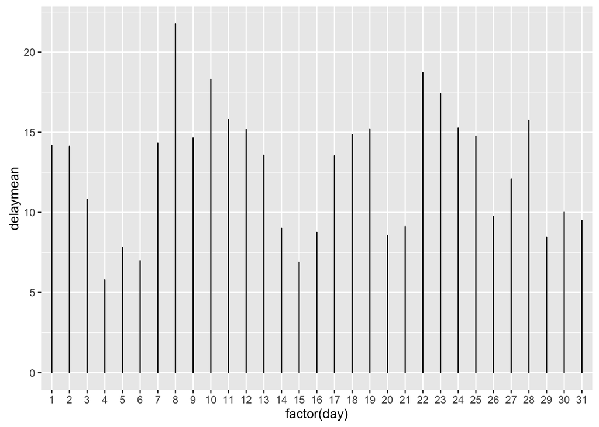

```r
flights.delaysum.sql_day <- tbl(sasha, "flights") %>%
  group_by(day) %>%
  summarize(
    delaymean = mean(dep_delay)
  )%>%collect()

flights.delaysum.sql_day <-data.frame(flights.delaysum.sql_day)

d <- ggplot(flights.delaysum.sql_day, aes(x= factor(day),y=delaymean)) + geom_density()
d
```

I can tell that 4th in a month got the lowest dep_delay 5.789,and 8th in a month got the highest dep_delay 21.96.

3.analyze between the departure and destination.

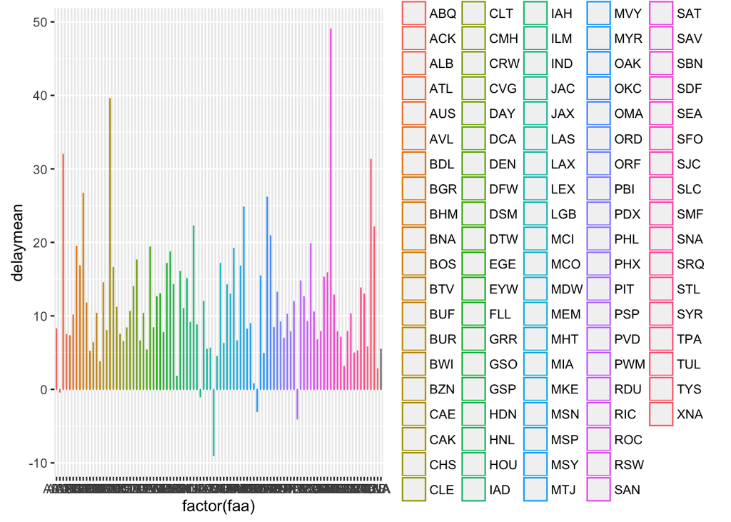

```r
flights_airports_join <- left_join(
  tbl(sasha, "flights"),
  tbl(sasha, "airports"),
  by = c("dest"="faa"))

flights_airports_join<-data.frame(flights_airports_join)
flights.airports_delay <- flights_airports_join %>%
  group_by(faa) %>%
  summarize(
    delaymean = mean(dep_delay,na.rm = T)
  )

order_flights.airports_delay<-arrange(flights.airports_delay,delaymean)

e <- ggplot(flights.airports_delay, aes(x= factor(faa),y=delaymean,colour = faa)) + geom_density()
e
```

LEX got the lowest departure delay -9,which means planes even arrive early in these two airports. SBN got the highest departure delay 49.

4.analyze the departure with plane Firstly, analyze the manufacturer

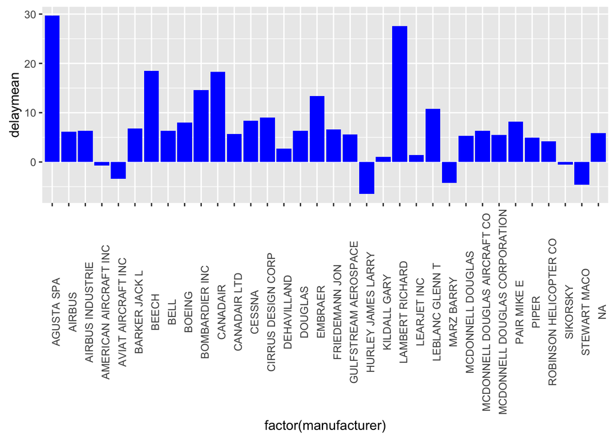

```r
flights_planes_join <- left_join(
  tbl(sasha, "flights"),
  tbl(sasha, "planes"),
  by = "tailnum")

flights_planes_join_1<-data.frame(flights_planes_join)
flights_planes_manufacturer_delay <- flights_planes_join_1 %>%
  group_by(manufacturer) %>%
  summarize(
    delaymean = mean(dep_delay,na.rm = T)
  )

order_planes_manufacturer_delay<-arrange(flights_planes_manufacturer_delay,delaymean)

f <- ggplot(flights_planes_manufacturer_delay, aes(x= factor(manufacturer),y=delaymean)) + geom_bar(stat="identity", fill = "blue")+ theme(axis.text.x=element_text(angle = 90))
f
```

HURLEY JAMES LARRY related to the lowest departure delay -6.5. AGUSTA SPA related to the highest departure delay 29.6923.

Secondly,analyze departure and year

```r
plane_delay<-na.omit(flights_planes_join)
glm_plane_delay_year<-glm(dep_delay~year.y,plane_delay,family=gaussian)
summary(glm_plane_delay_year)
```

```
##
## Call:
## glm(formula = dep_delay ~ year.y, family = gaussian, data = plane_delay)
##
## Deviance Residuals:
##     Min       1Q   Median       3Q      Max
##  -52.46   -14.38   -11.15    -2.15  1291.01
##
## Coefficients:
##               Estimate Std. Error t value Pr(>|t|)
## (Intercept) -144.32849   38.63740  -3.735 0.000187 ***
## year.y         0.07674    0.01930   3.975 7.03e-05 ***
## ---
## Signif. codes:  0 '***' 0.001 '**' 0.01 '*' 0.05 '.' 0.1 ' ' 1
##
## (Dispersion parameter for gaussian family taken to be 1191.549)
##
##     Null deviance: 97925988  on 82169  degrees of freedom
## Residual deviance: 97907158  on 82168  degrees of freedom
##   (17830 observations deleted due to missingness)
## AIC: 815203
##
## Number of Fisher Scoring iterations: 2
```

```r
glm_plane_delay_engines<-glm(dep_delay~engines,plane_delay,family=gaussian)
summary(glm_plane_delay_engines)
```

```
##
## Call:
## glm(formula = dep_delay ~ engines, family = gaussian, data = plane_delay)
##
## Deviance Residuals:
##     Min       1Q   Median       3Q      Max
##  -52.29   -14.29   -11.29    -2.29  1291.71
##
## Coefficients:
##             Estimate Std. Error t value Pr(>|t|)
## (Intercept)    5.272      2.545   2.071   0.0383 *
## engines        2.009      1.275   1.576   0.1151
## ---
## Signif. codes:  0 '***' 0.001 '**' 0.01 '*' 0.05 '.' 0.1 ' ' 1
##
## (Dispersion parameter for gaussian family taken to be 1193.201)
##
##     Null deviance: 99779609  on 83622  degrees of freedom
## Residual deviance: 99776647  on 83621  degrees of freedom
##   (16377 observations deleted due to missingness)
## AIC: 829734
##
## Number of Fisher Scoring iterations: 2
```

the coefficient before year,y is 0.07674, significant on 99%. the coefficient I got is 2.009, but not significant.

Thirdly, analyze engines and departure.

```r
flights_planes_engines_delay <- flights_planes_join_1 %>%
  group_by(engines) %>%
  summarize(
    delaymean = mean(dep_delay,na.rm = T)
  )

order_planes_engines_delay<-arrange(flights_planes_engines_delay,delaymean)
```

The planes with 1 engine depature delay is the lowest. The planes with 2 engines depature delay is the highest.

Forth, analyze engine and departure.

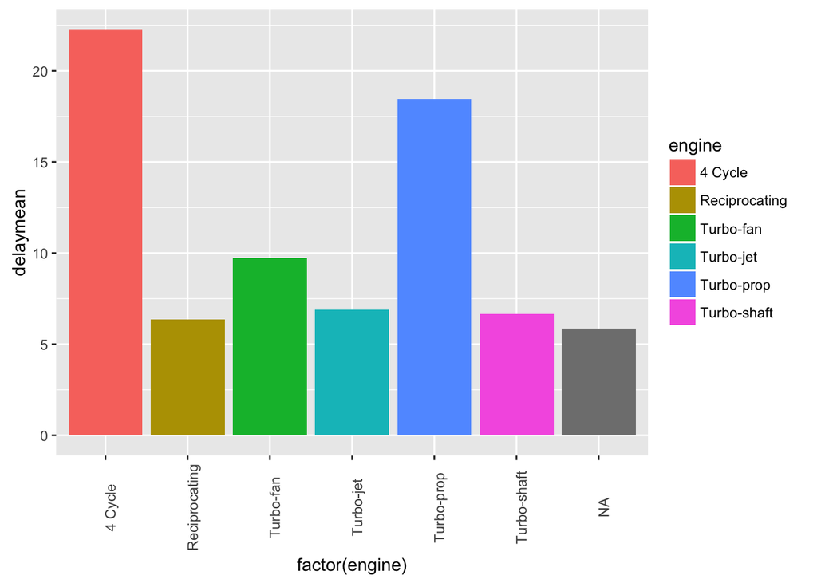

```r
flights_planes_engine_delay <- flights_planes_join_1 %>%
  group_by(engine) %>%
  summarize(
    delaymean = mean(dep_delay,na.rm = T)
  )
g <- ggplot(flights_planes_engine_delay, aes(x= factor(engine),y=delaymean,fill = engine)) + geom_bar(stat="identity")+ theme(axis.text.x=element_text(angle = 90))
g
```

The planes with 4 cycle engine delay depature is the highest. The planes with reciprocating engine delay depature is the lowest.

At last, analyse the departure and type of plane.

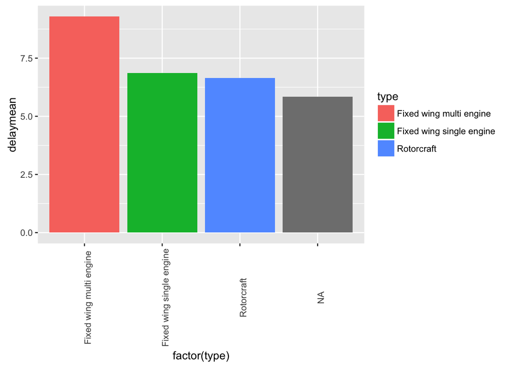

```r
flights_planes_type_delay <- flights_planes_join_1 %>%
  group_by(type) %>%
  summarize(
    delaymean = mean(dep_delay,na.rm = T)
  )
g <- ggplot(flights_planes_type_delay, aes(x= factor(type),y=delaymean,fill = type)) + geom_bar(stat="identity")+ theme(axis.text.x=element_text(angle = 90))
g
```

Fixed wing multi engine has the highest depature rate. Fixed wing single engine has the lower depature rate. Rotorcraft has the lowest departure rate.

part 2.cancelation with flights facets 1.analyze the cancelled with weather

```r
cancelled_flights_weather <- flights_sqlite %>% left_join(weather, by = "origin", copy = TRUE) %>% mutate(canceled = is.na(arr_time))

cancelled_flights_weather<-data.frame(cancelled_flights_weather)
glm_cancelled_temp<- glm(canceled~temp,cancelled_flights_weather,family=binomial(link=logit))
summary(glm_cancelled_temp)
```

```
##
## Call:
## glm(formula = canceled ~ temp, family = binomial(link = logit),
##     data = cancelled_flights_weather)
##
## Deviance Residuals:
##        Min          1Q      Median          3Q         Max
## -2.409e-06  -2.409e-06  -2.409e-06  -2.409e-06  -2.409e-06
##
## Coefficients:
##               Estimate Std. Error z value Pr(>|z|)
## (Intercept) -2.657e+01  3.576e+03  -0.007    0.994
## temp         1.012e-14  6.150e+01   0.000    1.000
##
## (Dispersion parameter for binomial family taken to be 1)
##
##     Null deviance: 0.0000e+00  on 99988  degrees of freedom
## Residual deviance: 5.8009e-07  on 99987  degrees of freedom
##   (11 observations deleted due to missingness)
## AIC: 4
##
## Number of Fisher Scoring iterations: 25
```

```r
glm_cancelled_pressure<- glm(canceled~pressure,cancelled_flights_weather,family=binomial(link=logit))
summary(glm_cancelled_pressure)
```

```
##
## Call:
## glm(formula = canceled ~ pressure, family = binomial(link = logit),
##     data = cancelled_flights_weather)
##
## Deviance Residuals:
##        Min          1Q      Median          3Q         Max
## -2.409e-06  -2.409e-06  -2.409e-06  -2.409e-06  -2.409e-06
##
## Coefficients:
##               Estimate Std. Error z value Pr(>|z|)
## (Intercept) -2.657e+01  1.638e+05       0        1
## pressure     1.496e-13  1.610e+02       0        1
##
## (Dispersion parameter for binomial family taken to be 1)
##
##     Null deviance: 0.0000e+00  on 89195  degrees of freedom
## Residual deviance: 5.1748e-07  on 89194  degrees of freedom
##   (10804 observations deleted due to missingness)
## AIC: 4
##
## Number of Fisher Scoring iterations: 25
```

```r
glm_cancelled_windspeed<- glm(canceled~wind_speed,cancelled_flights_weather,family=binomial(link=logit))
summary(glm_cancelled_windspeed)
```

```
##
## Call:
## glm(formula = canceled ~ wind_speed, family = binomial(link = logit),
##     data = cancelled_flights_weather)
##
## Deviance Residuals:
##        Min          1Q      Median          3Q         Max
## -2.409e-06  -2.409e-06  -2.409e-06  -2.409e-06  -2.409e-06
##
## Coefficients:
##               Estimate Std. Error z value Pr(>|z|)
## (Intercept) -2.657e+01  1.405e+03  -0.019    0.985
## wind_speed  -4.769e-14  8.962e+01   0.000    1.000
##
## (Dispersion parameter for binomial family taken to be 1)
##
##     Null deviance: 0.0000e+00  on 99987  degrees of freedom
## Residual deviance: 5.8009e-07  on 99986  degrees of freedom
##   (12 observations deleted due to missingness)
## AIC: 4
##
## Number of Fisher Scoring iterations: 25
```

All the coefficients are not significant, which means they should not be used to explain the chaning in cancellation.

2.analyze the cancelled with time.

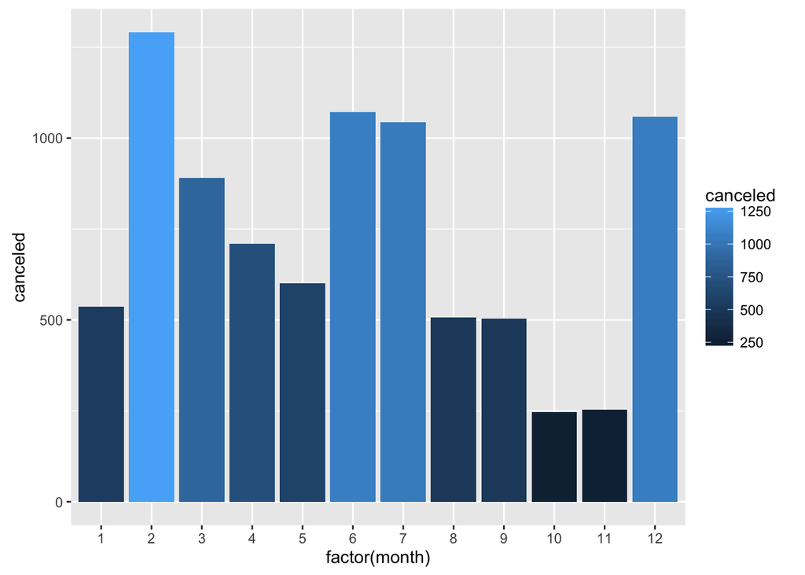

```r
flights_canceled = tbl(sasha, "flights") %>%
  collect() %>%
  mutate(canceled = is.na(arr_time))

flights_canceled<-data.frame(flights_canceled)

flights_canceled_month <- flights_canceled %>%
  group_by(month) %>%
  summarize(
    canceled = sum(canceled)
  )

order_flights_canceled_month<-arrange(flights_canceled_month,canceled)

h <- ggplot(flights_canceled_month, aes(x= factor(month),y=canceled,fill = canceled)) + geom_bar(stat="identity")
h
```

Oct has the least cancelation number 247, Feb has the most cancelation number 1291.

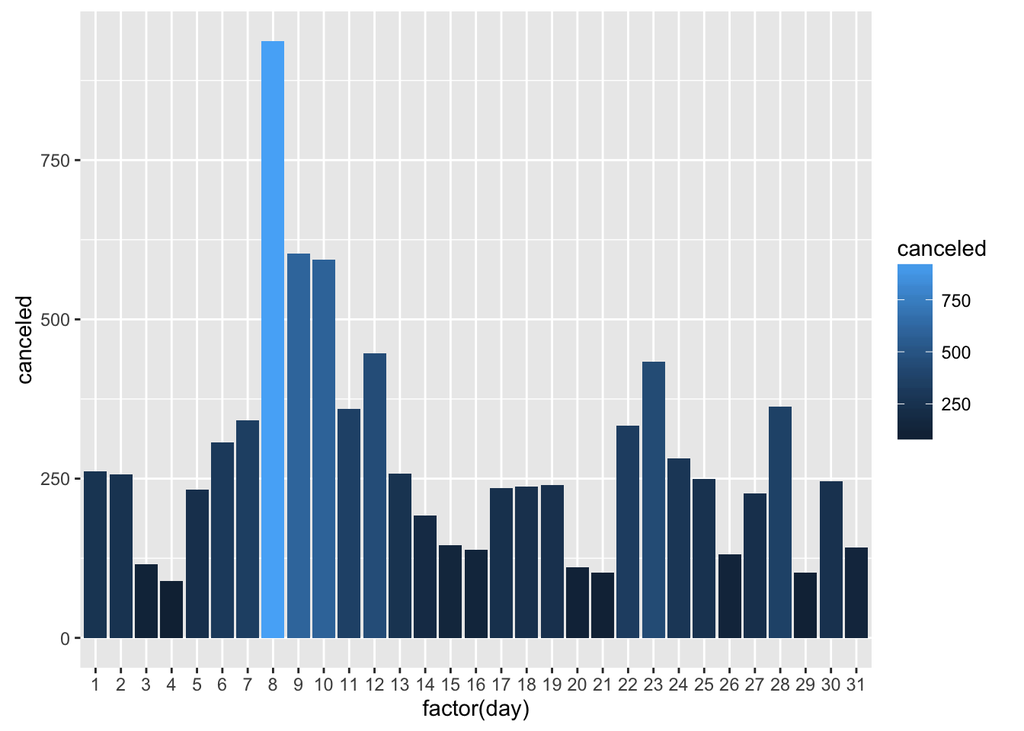

```r
flights_canceled_day <- flights_canceled %>%
  group_by(day) %>%
  summarize(
    canceled = sum(canceled)
  )

order_flights_canceled_day<-arrange(flights_canceled_day,canceled)

i <- ggplot(flights_canceled_day, aes(x= factor(day),y=canceled,fill = canceled)) + geom_bar(stat="identity")
i
```

3.analyze the canceled with destination

```r
cancelled_flights_airports <- flights_sqlite %>% left_join(airports, by = c("dest"="faa"), copy = TRUE) %>% mutate(canceled = is.na(arr_time))

cancelled_flights_airports<-data.frame(cancelled_flights_airports)

can_des <- cancelled_flights_airports %>%
  group_by(faa) %>%
  summarize(
    canceled = sum(canceled,na.rm = T)
  )

order_cancelled_flights_airports<-arrange(can_des,canceled)
```

ABQ ACK BUR BZN CAK CRW EGE EYW HDN HNL JAC LEX LGB MTJ MVY OAK PSP SBN SJC SMF all just canceled 0 times. DCA has 129 cancelation,the highest.

4.The relationship between calcellation and planes.

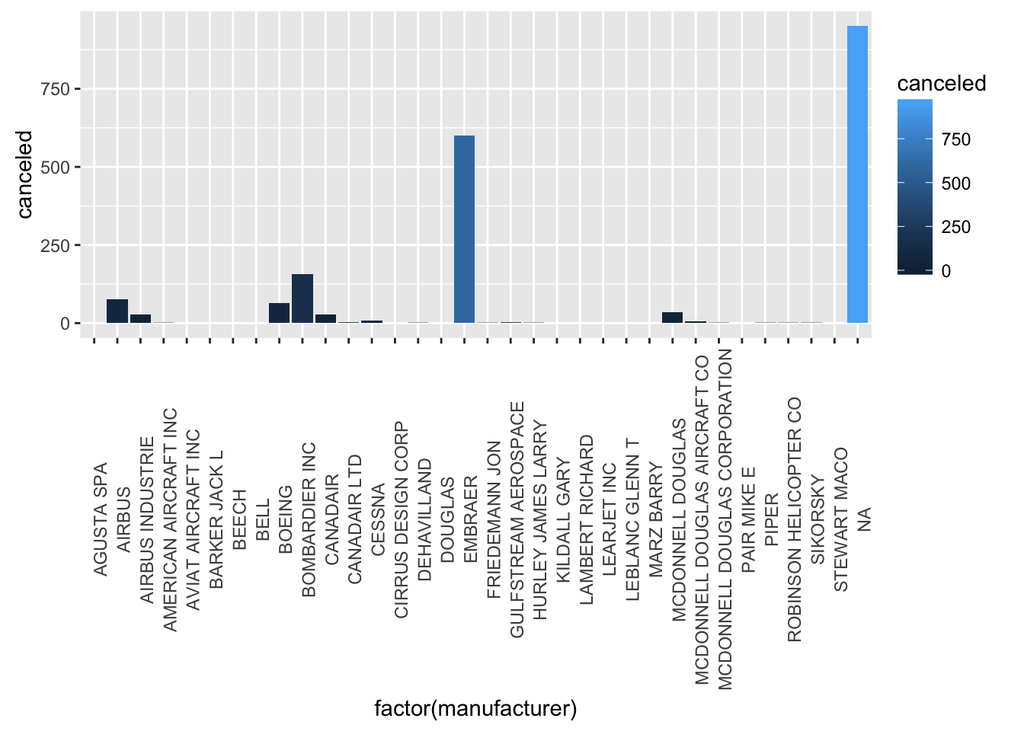

```r
cancelled_flights_planes <- flights_sqlite %>% left_join(planes, by = "tailnum", copy = TRUE) %>% mutate(canceled = is.na(arr_time))

cancelled_flights_planes<-data.frame(cancelled_flights_planes)

can_planes_year <- cancelled_flights_planes %>%
  group_by(year.y) %>%
  summarize(
    canceled = sum(canceled,na.rm = T)
  )

order_can_planes_year<-arrange(can_planes_year,canceled)

can_planes_manufacturer <- cancelled_flights_planes %>%
  group_by(manufacturer) %>%
  summarize(
    canceled = sum(canceled,na.rm = T)
  )

order_can_planes_manufacturer<-arrange(can_planes_manufacturer,canceled)

k <- ggplot(can_planes_manufacturer, aes(x= factor(manufacturer),y=canceled,fill = canceled)) + geom_bar(stat="identity")+ theme(axis.text.x=element_text(angle = 90))
k
```

2002 has 181 cancalations,which is the highest.

Embraer being cancelled for 600 times.But the second most just being cancelled for 157 times,maybe planes produced by Embraer easier to have problems.